# Project: Investigate TMDB Movie Dataset

- Introduction
- Data Wrangling
- Exploratory Data Analysis
- Conclusions

## Introduction

#### Dataset:

This movie database contains information about 10,000 movies including genres, ratings, revenue, budget, and more. It contains movies which are released between 1960 and 2015, it also has two columns for budget and revenue in terms of 2010 dollars accounting for inflation over time which will be used in my analysis.

#### Questions:

- how are the budget of making a movie changed over time?
- Which movies have the most and least profit?
- Which genres are most popular from year to year?
- What are Average runtime, budget and revenue of all the movies?
- What are the average runtimes of movies over the years?
- Which Runtime movies is most liked by the audiences according to the popularity?
- Which Production Companies have the highst profit?
- Which director has the most popular movies?
- Most Popular Keywords?
- What kinds of properties are associated with movies that have high revenues?

```python
import pandas as pd
import numpy as np
%matplotlib inline
from matplotlib import pyplot as plt
import seaborn as sns
from wordcloud import WordCloud, STOPWORDS
```

## Data Wrangling

### General Properties

```python
# Loading the data
df = pd.read_csv('tmdb-movies.csv')
df.head()
```

|  | id | imdb_id | popularity | budget | revenue | original_title | cast | homepage | director | tagline | ... | overview | runtime | genres | production_companies | release_date | vote_count | vote_average | release_year | budget_adj | revenue_adj |
| --- | --- | --- | --- | --- | --- | --- | --- | --- | --- | --- | --- | --- | --- | --- | --- | --- | --- | --- | --- | --- | --- |
| 0 | 135397 | tt0369610 | 32.985763 | 150000000 | 1513528810 | Jurassic World | Chris Pratt\|Bryce Dallas Howard\|Irrfan Khan\|Vi... | http://www.jurassicworld.com/ | Colin Trevorrow | The park is open. | ... | Twenty-two years after the events of Jurassic ... | 124 | Action\|Adventure\|Science Fiction\|Thriller | Universal Studios\|Amblin Entertainment\|Legenda... | 6/9/15 | 5562 | 6.5 | 2015 | 1.379999e+08 | 1.392446e+09 |
| 1 | 76341 | tt1392190 | 28.419936 | 150000000 | 378436354 | Mad Max: Fury Road | Tom Hardy\|Charlize Theron\|Hugh Keays-Byrne\|Nic... | http://www.madmaxmovie.com/ | George Miller | What a Lovely Day. | ... | An apocalyptic story set in the furthest reach... | 120 | Action\|Adventure\|Science Fiction\|Thriller | Village Roadshow Pictures\|Kennedy Miller Produ... | 5/13/15 | 6185 | 7.1 | 2015 | 1.379999e+08 | 3.481613e+08 |
| 2 | 262500 | tt2908446 | 13.112507 | 110000000 | 295238201 | Insurgent | Shailene Woodley\|Theo James\|Kate Winslet\|Ansel... | http://www.thedivergentseries.movie/#insurgent | Robert Schwentke | One Choice Can Destroy You | ... | Beatrice Prior must confront her inner demons ... | 119 | Adventure\|Science Fiction\|Thriller | Summit Entertainment\|Mandeville Films\|Red Wago... | 3/18/15 | 2480 | 6.3 | 2015 | 1.012000e+08 | 2.716190e+08 |
| 3 | 140607 | tt2488496 | 11.173104 | 200000000 | 2068178225 | Star Wars: The Force Awakens | Harrison Ford\|Mark Hamill\|Carrie Fisher\|Adam D... | http://www.starwars.com/films/star-wars-episod... | J.J. Abrams | Every generation has a story. | ... | Thirty years after defeating the Galactic Empi... | 136 | Action\|Adventure\|Science Fiction\|Fantasy | Lucasfilm\|Truenorth Productions\|Bad Robot | 12/15/15 | 5292 | 7.5 | 2015 | 1.839999e+08 | 1.902723e+09 |
| 4 | 168259 | tt2820852 | 9.335014 | 190000000 | 1506249360 | Furious 7 | Vin Diesel\|Paul Walker\|Jason Statham\|Michelle ... | http://www.furious7.com/ | James Wan | Vengeance Hits Home | ... | Deckard Shaw seeks revenge against Dominic Tor... | 137 | Action\|Crime\|Thriller | Universal Pictures\|Original Film\|Media Rights ... | 4/1/15 | 2947 | 7.3 | 2015 | 1.747999e+08 | 1.385749e+09 |

5 rows × 21 columns

```python
df.info()
```

```
<class 'pandas.core.frame.DataFrame'>
RangeIndex: 10866 entries, 0 to 10865
Data columns (total 21 columns):
 #   Column                Non-Null Count  Dtype
---  ------                --------------  -----
 0   id                    10866 non-null  int64
 1   imdb_id               10856 non-null  object
 2   popularity            10866 non-null  float64
 3   budget                10866 non-null  int64
 4   revenue               10866 non-null  int64
 5   original_title        10866 non-null  object
 6   cast                  10790 non-null  object
 7   homepage              2936 non-null   object
 8   director              10822 non-null  object
 9   tagline               8042 non-null   object
 10  keywords              9373 non-null   object
 11  overview              10862 non-null  object
 12  runtime               10866 non-null  int64
 13  genres                10843 non-null  object
 14  production_companies  9836 non-null   object
 15  release_date          10866 non-null  object
 16  vote_count            10866 non-null  int64
 17  vote_average          10866 non-null  float64
 18  release_year          10866 non-null  int64
 19  budget_adj            10866 non-null  float64
 20  revenue_adj           10866 non-null  float64
dtypes: float64(4), int64(6), object(11)
memory usage: 1.7+ MB
```

```python
df.describe()
```

|  | id | popularity | budget | revenue | runtime | vote_count | vote_average | release_year | budget_adj | revenue_adj |
| --- | --- | --- | --- | --- | --- | --- | --- | --- | --- | --- |
| count | 10866.000000 | 10866.000000 | 1.086600e+04 | 1.086600e+04 | 10866.000000 | 10866.000000 | 10866.000000 | 10866.000000 | 1.086600e+04 | 1.086600e+04 |
| mean | 66064.177434 | 0.646441 | 1.462570e+07 | 3.982332e+07 | 102.070863 | 217.389748 | 5.974922 | 2001.322658 | 1.755104e+07 | 5.136436e+07 |
| std | 92130.136561 | 1.000185 | 3.091321e+07 | 1.170035e+08 | 31.381405 | 575.619058 | 0.935142 | 12.812941 | 3.430616e+07 | 1.446325e+08 |
| min | 5.000000 | 0.000065 | 0.000000e+00 | 0.000000e+00 | 0.000000 | 10.000000 | 1.500000 | 1960.000000 | 0.000000e+00 | 0.000000e+00 |
| 25% | 10596.250000 | 0.207583 | 0.000000e+00 | 0.000000e+00 | 90.000000 | 17.000000 | 5.400000 | 1995.000000 | 0.000000e+00 | 0.000000e+00 |
| 50% | 20669.000000 | 0.383856 | 0.000000e+00 | 0.000000e+00 | 99.000000 | 38.000000 | 6.000000 | 2006.000000 | 0.000000e+00 | 0.000000e+00 |
| 75% | 75610.000000 | 0.713817 | 1.500000e+07 | 2.400000e+07 | 111.000000 | 145.750000 | 6.600000 | 2011.000000 | 2.085325e+07 | 3.369710e+07 |
| max | 417859.000000 | 32.985763 | 4.250000e+08 | 2.781506e+09 | 900.000000 | 9767.000000 | 9.200000 | 2015.000000 | 4.250000e+08 | 2.827124e+09 |

```python
df.isna().sum()
```

```
id                         0
imdb_id                   10
popularity                 0
budget                     0
revenue                    0
original_title             0
cast                      76
homepage                7930
director                  44
tagline                 2824
keywords                1493
overview                   4
runtime                    0
genres                    23
production_companies    1030
release_date               0
vote_count                 0
vote_average               0
release_year               0
budget_adj                 0
revenue_adj                0
dtype: int64
```

```python
df.duplicated().sum()
```

```
1
```

### First thoughts

- Some columns aren't needed in the analysis which i will drop (id, imdb_id, budget, revenue, cast, homepage, tagline, overview, release_date, vote_count, vote_average)
- number of votes differ for each movie , so vote_count and vote_average might not be useful.
- some rows have NaN values which i will drop.
- some rows has 0 budget and revanue which i think is a missing data so i will drop them too.
- there is only 1 duplicate row which i will drop.

### Data Cleaning

```python
#dropping unuseful columns
df.drop(labels =['id', 'imdb_id', 'budget', 'revenue', 'cast', 'homepage', 'tagline', 'overview', 'release_date', 'vote_count', 'vote_average'],
        axis=1, inplace=True)
df.shape
```

```
(10866, 10)
```

```python
#dropping NaN rows
df.dropna(inplace=True)
df.isna().sum()
```

```
popularity              0
original_title          0
director                0
keywords                0
runtime                 0
genres                  0
production_companies    0
release_year            0
budget_adj              0
revenue_adj             0
dtype: int64
```

```python
#dropping duplicated row
df.drop_duplicates(inplace=True)
df.duplicated().sum()
```

```
0
```

```python
#dropping rows with zeros
df['budget_adj'] = df['budget_adj'].replace(0, np.NaN)
df['revenue_adj'] = df['revenue_adj'].replace(0, np.NaN)
df.dropna(inplace=True)
df.isna().sum()
```

```
popularity              0
original_title          0
director                0
keywords                0
runtime                 0
genres                  0
production_companies    0
release_year            0
budget_adj              0
revenue_adj             0
dtype: int64
```

## Exploratory Data Analysis

### Question 1: How are the budget of making a movie changed over time?

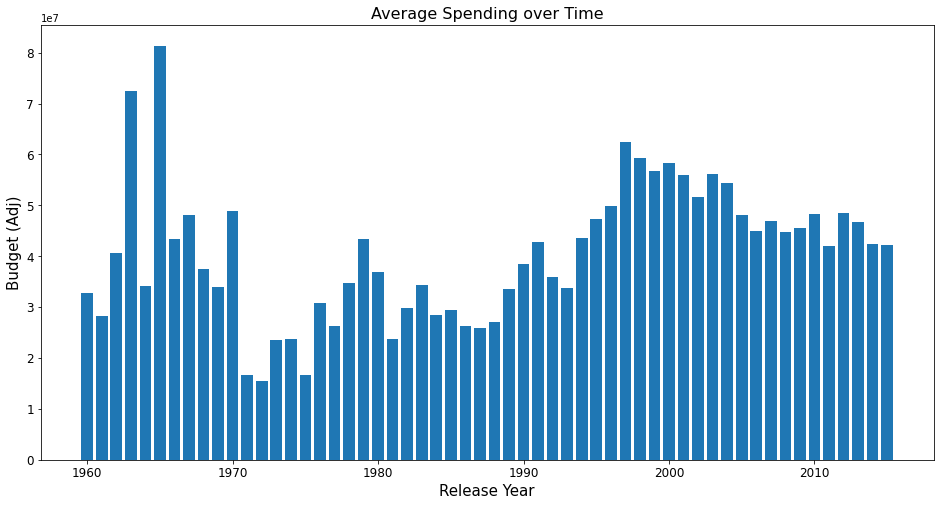

```python
#plotting barplot for Average Budget over time
x=df.groupby('release_year').budget_adj.mean().index
h=df.groupby('release_year').budget_adj.mean().values
plt.figure(figsize=(16,8))
plt.bar(x=x,height=h);
plt.xlabel('Release Year',size=15)
plt.xticks(size=12)
plt.ylabel('Budget (Adj)',size=15)
plt.yticks(size=12)
plt.title('Average Spending over Time',size=16);
```

##### The above figure shows ups and downs then a growth in spending starting around 1970s.

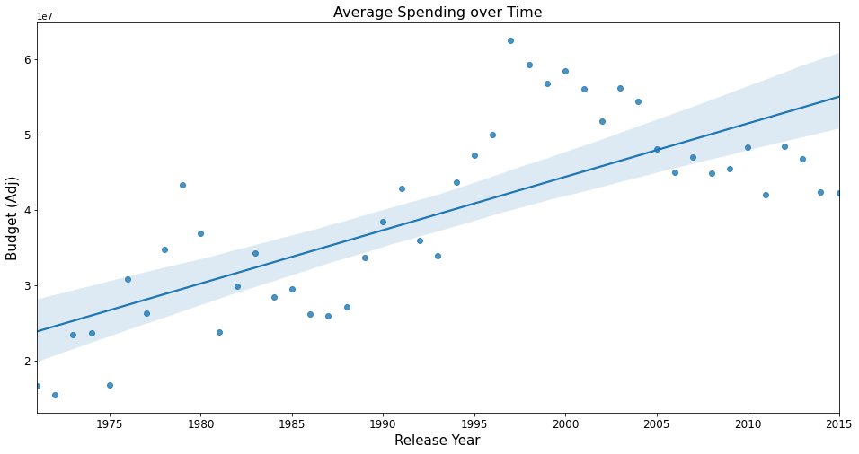

```python
#Plot data and a linear regression model fit for spending over time
df_bud = df.query("release_year > 1970").groupby('release_year').budget_adj.mean()
x=df_bud.index
y=df_bud.values
plt.figure(figsize=(16,8))
sns.regplot(x,y)
plt.xlabel('Release Year',size=15)
plt.xticks(size=12)
plt.ylabel('Budget (Adj)',size=15)
plt.yticks(size=12)
plt.title('Average Spending over Time',size=16);
```

### Question 2 : Which movies have the most and least profit?

```python
#making new column for profit
df['profit'] = df['revenue_adj'] - df['budget_adj']
#finding movies with highest and lowest profit
lowest =  pd.DataFrame(df.loc[df['profit'].idxmin()])
highest = pd.DataFrame(df.loc[df['profit'].idxmax()])
high_low = pd.concat([highest, lowest],axis=1)
high_low
```

|  | 1329 | 2244 |
| --- | --- | --- |
| popularity | 12.0379 | 0.25054 |
| original_title | Star Wars | The Warrior's Way |
| director | George Lucas | Sngmoo Lee |
| keywords | android\|galaxy\|hermit\|death star\|lightsaber | assassin\|small town\|revenge\|deception\|super speed |
| runtime | 121 | 100 |
| genres | Adventure\|Action\|Science Fiction | Adventure\|Fantasy\|Action\|Western\|Thriller |
| production_companies | Lucasfilm\|Twentieth Century Fox Film Corporation | Boram Entertainment Inc. |
| release_year | 1977 | 2010 |
| budget_adj | 3.95756e+07 | 4.25e+08 |
| revenue_adj | 2.78971e+09 | 1.10876e+07 |
| profit | 2.75014e+09 | -4.13912e+08 |

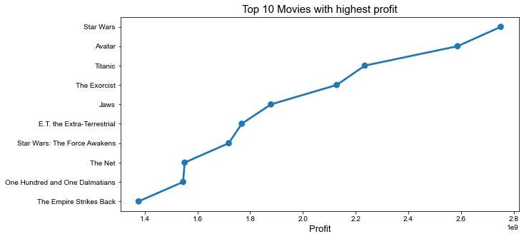

```python
#plotting pointplot for highest profitable movies
df_pf = pd.DataFrame(df['profit'].sort_values(ascending = False))
df_pf['original_title'] = df['original_title']
plt.figure(figsize=(10,5));
ax = sns.pointplot(y=df_pf['original_title'][:10],x=df_pf['profit'][:10])
ax.set_title("Top 10 Movies with highest profit",fontsize = 15)
ax.set_xlabel("Profit",fontsize = 13)
ax.set_ylabel('')
sns.set_style("whitegrid")
```

##### from the figures above 'Star Wars' movie Directed by George Lucas earn the highest profit in all, making over 2.7B in profit in this dataset.And the most in loss movie is The Warrior's Way. Going in loss by more than 400M was directed by Singmoo Lee.

### Question 3 : Which genre are most popular from year to year?

```python
#splitting genres
df_gen=df[['genres','release_year','popularity']].copy()
df_gen['genres'] = df_gen['genres'].str.split('|')
gen = df_gen.apply(lambda x: pd.Series(x['genres']),axis=1).stack().reset_index(level=1, drop=True)
gen.name = 'genres'
df_gen.drop('genres',axis=1,inplace=True)
df_gen=df_gen.join(gen)
df_gen
```

|  | release_year | popularity | genres |
| --- | --- | --- | --- |
| 0 | 2015 | 32.985763 | Action |
| 0 | 2015 | 32.985763 | Adventure |
| 0 | 2015 | 32.985763 | Science Fiction |
| 0 | 2015 | 32.985763 | Thriller |
| 1 | 2015 | 28.419936 | Action |
| ... | ... | ... | ... |
| 10835 | 1966 | 0.299911 | Drama |
| 10835 | 1966 | 0.299911 | War |
| 10835 | 1966 | 0.299911 | Romance |
| 10848 | 1966 | 0.207257 | Adventure |
| 10848 | 1966 | 0.207257 | Science Fiction |

9860 rows × 3 columns

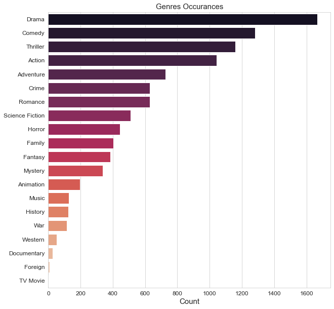

```python
#plotting barplot for most frequent genres
x=df_gen['genres'].value_counts().index
y=df_gen['genres'].value_counts().values
plt.figure(figsize=(10,10));
sns.barplot(y,x,orient='h',palette="rocket");
plt.xlabel('Count',size=15);
plt.xticks(size=12)
plt.yticks(size=12)
plt.title('Genres Occurances',size=15);
```

##### from the figure above Drama has the highest number of released movies followed by Comedy

```python
#splitting genres into Decades
df_gen_60 = df_gen.query(" 1960 <= release_year <= 1969").groupby('genres').popularity.sum().sort_values(ascending=False)
df_gen_70 = df_gen.query(" 1970 <= release_year <= 1979").groupby('genres').popularity.sum().sort_values(ascending=False)
df_gen_80 = df_gen.query(" 1980 <= release_year <= 1989").groupby('genres').popularity.sum().sort_values(ascending=False)
df_gen_90 = df_gen.query(" 1990 <= release_year <= 1999").groupby('genres').popularity.sum().sort_values(ascending=False)
df_gen_20 = df_gen.query(" 2000 <= release_year <= 2009").groupby('genres').popularity.sum().sort_values(ascending=False)
df_gen_21 = df_gen.query(" 2010 <= release_year").groupby('genres').popularity.sum().sort_values(ascending=False)
```

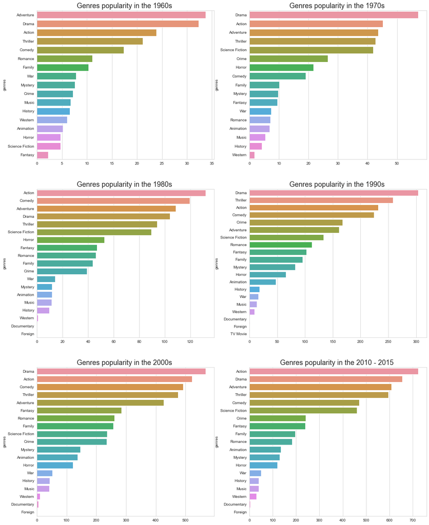

```python
#plotting most popular genres for each decade
fig, axs = plt.subplots(3, 2,figsize=(18,24));
x=df_gen_60.index
y=df_gen_60.values
ax= sns.barplot(y,x,orient='h',ax=axs[0,0]);
ax.set_title('Genres popularity in the 1960s ',size=18);

x=df_gen_70.index
y=df_gen_70.values
ax = sns.barplot(y,x,orient='h',ax=axs[0,1]);
ax.set_title('Genres popularity in the 1970s ',size=18);

x=df_gen_80.index
y=df_gen_80.values
ax= sns.barplot(y,x,orient='h',ax=axs[1,0]);
ax.set_title('Genres popularity in the 1980s ',size=18);

x=df_gen_90.index
y=df_gen_90.values
ax = sns.barplot(y,x,orient='h',ax=axs[1,1]);
ax.set_title('Genres popularity in the 1990s ',size=18);

x=df_gen_20.index
y=df_gen_20.values
ax = sns.barplot(y,x,orient='h',ax=axs[2,0]);
ax.set_title('Genres popularity in the 2000s ',size=18);

x=df_gen_21.index
y=df_gen_21.values
ax = sns.barplot(y,x,orient='h',ax=axs[2,1]);
ax.set_title('Genres popularity in the 2010 - 2015 ',size=18);
```

##### most frequently entered genres in the top 5 (in terms of popularity) in each decade are:

- Drama
- Action
- Comedy
- Thriller
- Adventure

### Question 4: What are Average runtime, budget and revenue of all the movies?

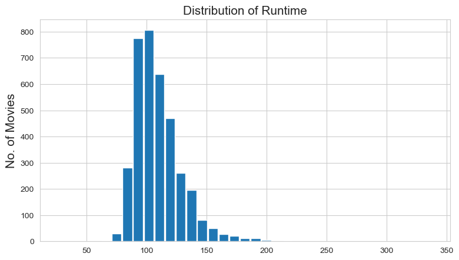

```python
#plotting a histogram of runtime of movies
plt.figure(figsize=(9,5), dpi = 100);
plt.ylabel('No. of Movies', fontsize=15);
plt.title('Distribution of Runtime', fontsize=15);
plt.hist(df['runtime'], rwidth = 0.9, bins =35);
```

##### The distribution of the above graph is right skewed, Most of the movies are timed between 90 to 110 minutes.

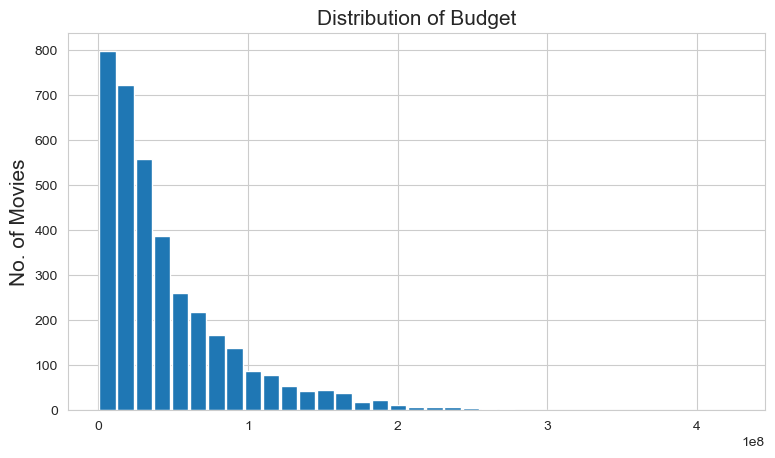

```python
#plotting a histogram of Budget of movies
plt.figure(figsize=(9,5), dpi = 100);
plt.ylabel('No. of Movies', fontsize=15);
plt.title('Distribution of Budget', fontsize=15);
plt.hist(df['budget_adj'], rwidth = 0.9, bins =35);
```

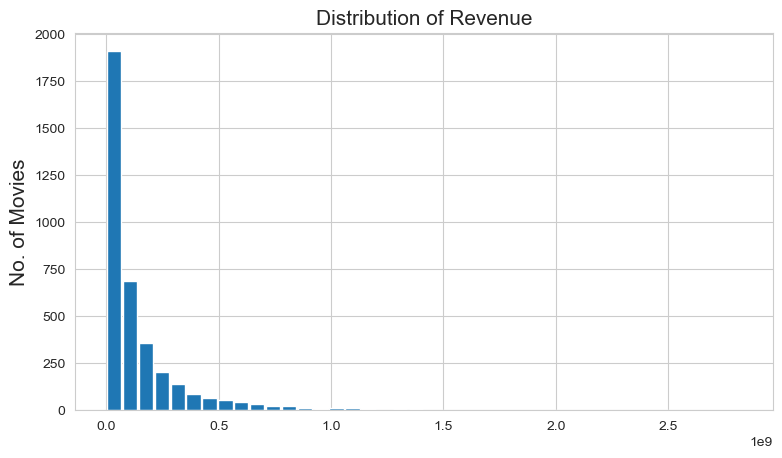

```python
#plotting a histogram of revenue of movies
plt.figure(figsize=(9,5), dpi = 100);
plt.ylabel('No. of Movies', fontsize=15);
plt.title('Distribution of Revenue', fontsize=15);
plt.hist(df['revenue_adj'], rwidth = 0.9, bins =40);
```

### Question 5: What are the average runtimes of movies over the years?

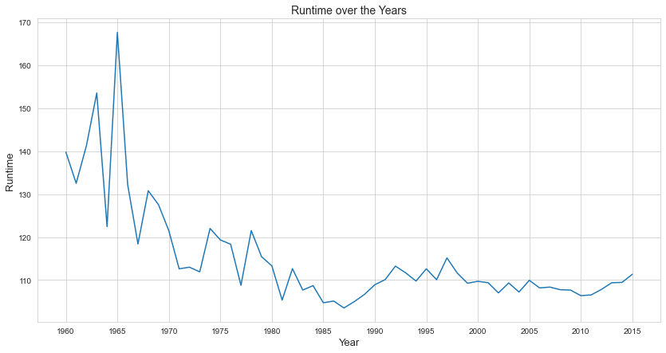

```python
plt.figure(figsize=(14,7));
df_run= df.groupby('release_year').runtime.mean().plot(xticks = np.arange(1960,2016,5))
plt.title("Runtime over the Years",fontsize = 14)
plt.xlabel('Year',fontsize = 13)
plt.ylabel('Runtime',fontsize = 13)
```

##### from the figure above we can see that the runtime is decreasing over years , with average runtime arround 110 Minutes.

### Question 6: Which Runtime movies is most liked by the audiences according to the popularity?

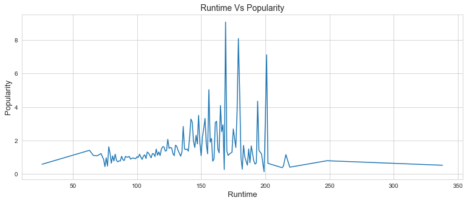

```python
df.groupby('runtime').popularity.mean().plot(figsize = (13,5))
plt.title("Runtime Vs Popularity",fontsize = 14)
plt.xlabel('Runtime',fontsize = 13)
plt.ylabel('Popularity',fontsize = 13)
sns.set(rc={'figure.figsize':(10,5)})
sns.set_style("whitegrid")
```

##### from the figure we can see that movies in the range of 150-200 runtime are more popular than other runtime movies.

### Question 7: Which Production Companies have the highst profit?

```python
#splitting production companies
df_prod = df[['production_companies','profit']].copy()
df_prod['production_companies'] = df_prod['production_companies'].str.split('|')
prod = df_prod.apply(lambda x: pd.Series(x['production_companies']),axis=1).stack().reset_index(level=1, drop=True)
prod.name = 'production_companies'
df_prod.drop('production_companies',axis=1,inplace=True)
df_prod=df_prod.join(prod)
df_prod
```

|  | profit | production_companies |
| --- | --- | --- |
| 0 | 1.254446e+09 | Universal Studios |
| 0 | 1.254446e+09 | Amblin Entertainment |
| 0 | 1.254446e+09 | Legendary Pictures |
| 0 | 1.254446e+09 | Fuji Television Network |
| 0 | 1.254446e+09 | Dentsu |
| ... | ... | ... |
| 10829 | 9.049166e+06 | Laurel Productions |
| 10835 | 5.374412e+07 | Twentieth Century Fox Film Corporation |
| 10835 | 5.374412e+07 | Solar Productions |
| 10835 | 5.374412e+07 | Robert Wise Productions |
| 10848 | 4.625353e+07 | Twentieth Century Fox Film Corporation |

10229 rows × 2 columns

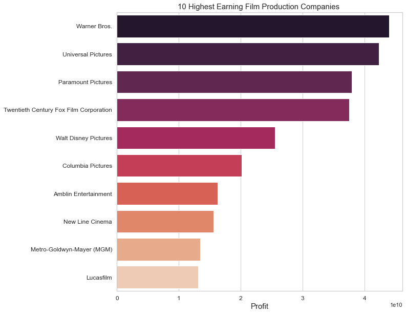

```python
#plotting barplot for highest earning production companies
top_prod = df_prod.groupby('production_companies').profit.sum().sort_values(ascending=False)[:10]
x=top_prod.index
y=top_prod.values
plt.figure(figsize=(10,10));
sns.barplot(y,x,orient='h',palette="rocket");
plt.xlabel('Profit',size=15);
plt.ylabel('');
plt.xticks(size=12)
plt.yticks(size=12)
plt.title('10 Highest Earning Film Production Companies ',size=15);
```

##### from the figure we can see that Warner Bros. is the Highest Earning Film Production Company followed by Universal Pictures.

### Question 8: Which director has the most popular movies?

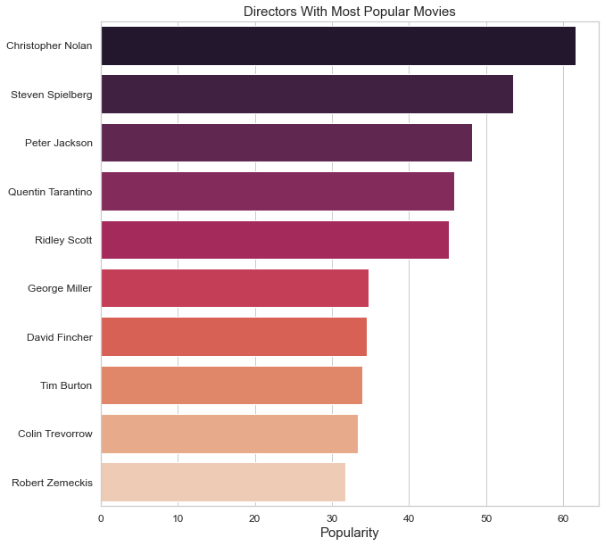

```python
#plotting barplot for directors with most popular movies
top_dir = df.groupby('director').popularity.sum().sort_values(ascending=False)[:10]
x=top_dir.index
y=top_dir.values
plt.figure(figsize=(10,10));
sns.barplot(y,x,orient='h',palette="rocket");
plt.xlabel('Popularity',size=15);
plt.ylabel('');
plt.xticks(size=12)
plt.yticks(size=12)
plt.title('Directors With Most Popular Movies',size=15);
```

##### from the figure we can see that christopher nolan has the most popular movies followed by steven spielberg.

### Question 9: Most Popular Keywords?

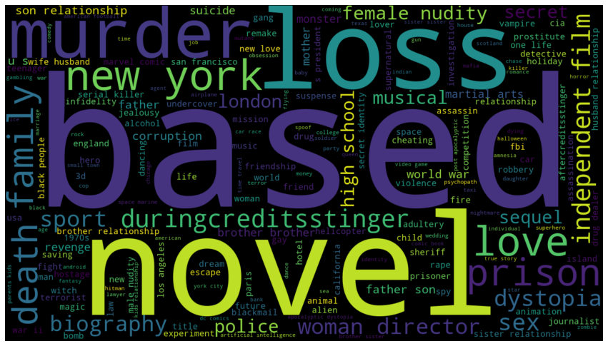

```python
#word cloud for most used keywords
text = df.keywords.str.cat(sep='|')
plt.figure( figsize=(15,10))
wordcloud = WordCloud(width=1280, height=720,background_color="black").generate(text)
plt.imshow(wordcloud, interpolation='bilinear')
plt.axis("off")
plt.show()
```

### Question 10: What kinds of properties are associated with movies that have high revenues?

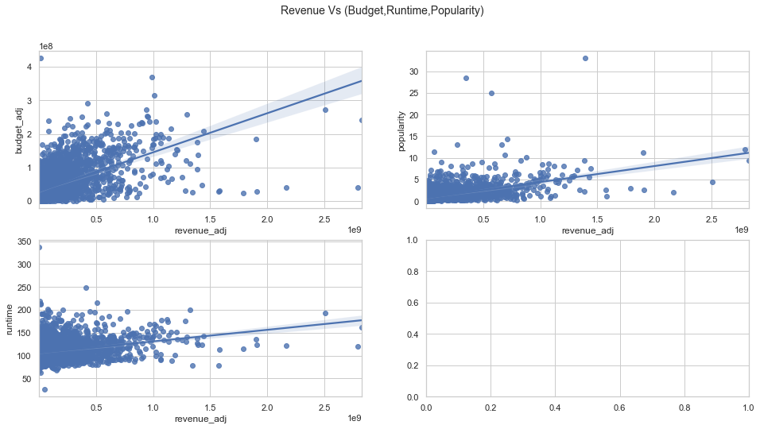

```python
#plotting scatterplot to find properties that associated with high revenues movies
fig, axes = plt.subplots(2,2,figsize = (16,8))
x=df['revenue_adj']
fig.suptitle("Revenue Vs (Budget,Runtime,Popularity)",fontsize=14)
sns.regplot(x, y=df['budget_adj'],ax=axes[0,0])
sns.regplot(x, y=df['runtime'],ax=axes[1,0])
sns.regplot(x, y=df['popularity'],ax=axes[0,1])
sns.set_style("whitegrid")
```

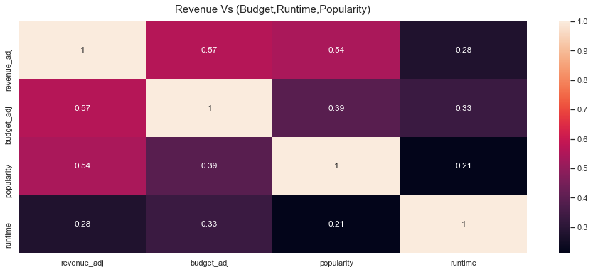

```python
#correlation heatmap to find properties that associated with high revenues movies
corr = df[['revenue_adj','budget_adj','popularity','runtime']].corr()
plt.figure(figsize=(16, 6))
heatmap = sns.heatmap(corr,annot=True)
heatmap.set_title('Revenue Vs (Budget,Runtime,Popularity)', fontdict={'fontsize':15}, pad=12);
```

- *Budget vs Revenue:*

  we can see that the revenues increase slightly at higher levels (moderate Correlation), So There is a possibility that movies with higher investments result in better revenues.

  Correlation = 0.57
- *Popularity vs Revenue:*

  we can see that the revenue seems to be slightly increasing with popularity (moderate Correlation), We can say that movies with higher Popularity get higher revenue.

  Correlation = 0.54
- *Runtime vs Revenue:*

  The correlation between revenue and runtime is 0.28 (weak corelation). So runtime is not highly related to the revenue.

## Limitation:

- there are many data that was removed such as rows contained 0 and null values.
- It should be noted that these this analysis does not imply any causation.